# 615 fridge

Yukun He, Kailun Huang, Shijie Cai, Fei Shi

10/09/2017

Our group want to see how different income would influence the size, type and age of the fridgertors be purchased. Through our data exploratory, we hope to find a good strategy for the refrigerators market. To do so, we choose the dataset from the U.S Energy Information Administration website under the category Appliances by Household income.

```r
##Load the all the .csv files from the directory into the environment.
list_filenames <- list.files(pattern="*.csv")
list_data <- list()

for (i in 1:length(list_filenames))
{
list_data[[i]] <- read.csv(list_filenames[i])
}
names(list_data)<-list_filenames
```

```r
##Extract all the .csv files into seperate datasets.
income_data <- as.data.frame(list_data[1])##Whole income data
size_data <- as.data.frame(list_data[2])
type_data <- as.data.frame(list_data[3])##These two are datasets mannually collated into .csv files.
income_data <- income_data[101:165, ] ##This is the part about fridge in the big dataset.

colnames(income_data) <- c("","total","<20,000","20,000 - 39,999","40,000 - 59,999","60,000 - 79,999","80,000 - 99,999","100,000 - 119,999","120,000 - 139,999","140,000<")
```

### Number of fridges

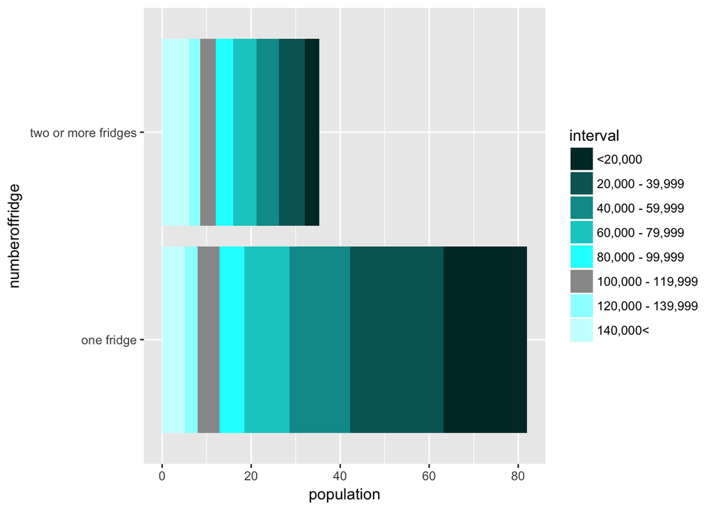

```r
##Using dplyr to collate and rearrange the data for number of fridges.
income_chart_1_data <- as.data.frame(t(income_data[3:4,-c(1,2)]))

colnames(income_chart_1_data) <- c("population","two_or_more_fridge")
income_chart_1_data <- rownames_to_column(income_chart_1_data, var="interval")

two <- select(income_chart_1_data, "interval", "two_or_more_fridge")
colnames(two)  <- c("interval","population")
income_chart_1_data <- bind_rows(income_chart_1_data[ , -3], two)
income_chart_1_data <- mutate(income_chart_1_data, numberoffridge = "one fridge")
income_chart_1_data[9:16, 3] = "two or more fridges"

income_chart_1_data[ , 1] <- sapply(income_chart_1_data[ , 1], as.factor)
income_chart_1_data[ , 2] <- sapply(income_chart_1_data[ , 2], as.numeric)
income_chart_1_data[ , 3] <- sapply(income_chart_1_data[ , 3], as.factor)

##ggplot
income1 <- ggplot() + geom_bar(data = income_chart_1_data, aes(y = population, x = numberoffridge, fill = interval), stat = "identity") + scale_fill_manual(values = c("#003333","#006666","#009999","#00CCCC","#00FFFF","#999999","#99FFFF","#CCFFFF")) + coord_flip()
income1
```

From the first graph, we found out that for those families that only have one refrigerator, those families which household income is below 40000 dollar weighed about 50 percent. However, for those families that have two or more refrigerators, those families which household income is below 40000 dollar weighed only about 20 percent. This means income is a determinant in deciding whether a family would like to buy one more refrigerators.

### SIZE

```r
##Directly use the data that was previously manually collated.
income_chart_2_data <- size_data
as.factor(income_chart_2_data$income)
```

```
## factor(0)
## Levels:
```

```r
as.factor(income_chart_2_data$populations)
```

```
## factor(0)
## Levels:
```

```r
as.factor(income_chart_2_data$size)
```

```
## factor(0)
## Levels:
```

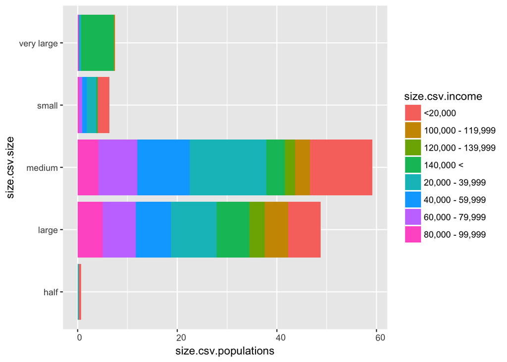

```r
##ggplot
size <- ggplot() + geom_bar(aes(y = size.csv.populations, x = size.csv.size, fill = size.csv.income), data = income_chart_2_data, stat = "identity")

size <- size + theme(axis.text.x  = element_text(angle = 1,hjust = 0.1)) + coord_flip()
size
```

### TYPE

```r
##Directly use the data that was previously manually collated.
income_chart_3_data <- type_data
as.factor(income_chart_3_data$income)
```

```
## factor(0)
## Levels:
```

```r
as.factor(income_chart_3_data$populationt)
```

```
## factor(0)
## Levels:
```

```r
as.factor(income_chart_3_data$type)
```

```
## factor(0)
## Levels:
```

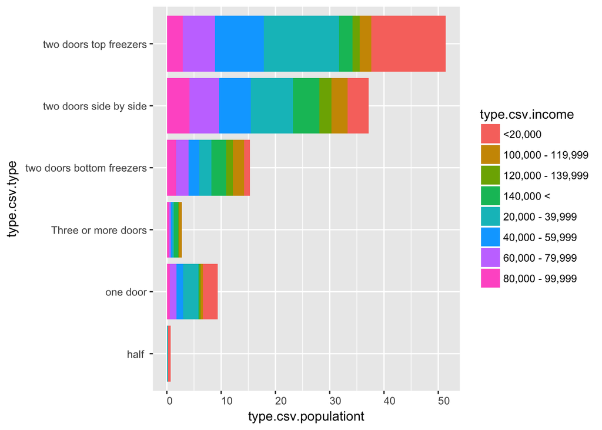

```r
##ggplot
type <- ggplot() + geom_bar(aes(y = type.csv.populationt, x = type.csv.type, fill = type.csv.income), data = income_chart_3_data, stat = "identity")

type<-type+theme(axis.text.x  = element_text(angle=1,hjust = 0.01))+coord_flip()
type
```

From the third plot we found out that two doors with top freezers refrigerator is the most popular type in the market cause about fifty percent of families own this type. For all types of refrigerators we found out each income interval is normally distributed. Thus, we want to conclude types of refrigerators are only families’ interests.

### AGE

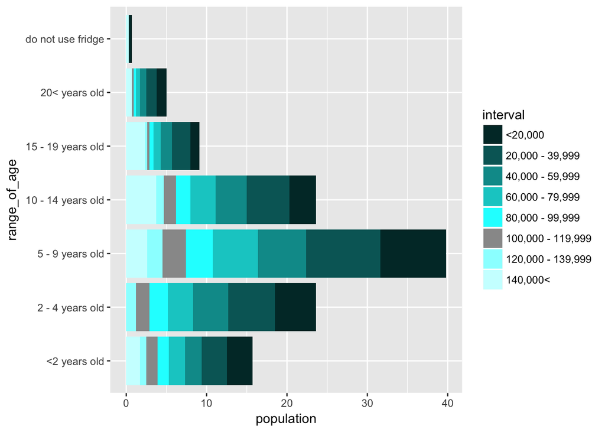

```r
##Using dplyr to collated and rearrange the data for interval of ages.
income_chart_4_data <- as.data.frame(t(income_data[22:28,-c(1,2)]))

colnames(income_chart_4_data) <- c("population","2 - 4 years old","5 - 9 years old","10 - 14 years old","15 - 19 years old","20< years old","do not use fridge")

income_chart_4_data <- rownames_to_column(income_chart_4_data, var="interval")

two_four <- select(income_chart_4_data, "interval", "2 - 4 years old")
colnames(two_four)  <- c("interval","population")

income_chart_4_data <- bind_rows(income_chart_4_data[ , -3], two_four)
five_nine <- select(income_chart_4_data, "interval", "5 - 9 years old")
colnames(five_nine)  <- c("interval","population")

income_chart_4_data <- bind_rows(income_chart_4_data[ , -3], five_nine[-c(9:16), ])
ten_fourteen <- select(income_chart_4_data, "interval", "10 - 14 years old")
colnames(ten_fourteen)  <- c("interval","population")

income_chart_4_data <- bind_rows(income_chart_4_data[ , -3], ten_fourteen[-c(9:24), ])
fifteen_nineteen <- select(income_chart_4_data, "interval", "15 - 19 years old")
colnames(fifteen_nineteen)  <- c("interval","population")

income_chart_4_data <- bind_rows(income_chart_4_data[ , -3], fifteen_nineteen[-c(9:32), ])
twenty <- select(income_chart_4_data, "interval", "20< years old")
colnames(twenty)  <- c("interval","population")

income_chart_4_data <- bind_rows(income_chart_4_data[ , -3], twenty[-c(9:40), ])
no_fridge <- select(income_chart_4_data, "interval", "do not use fridge")
colnames(no_fridge)  <- c("interval","population")

income_chart_4_data <- bind_rows(income_chart_4_data[ , -3], no_fridge[-c(9:48), ])
income_chart_4_data <- mutate(income_chart_4_data, range_of_age = "<2 years old")
income_chart_4_data[9:16, 3] = "2 - 4 years old"
income_chart_4_data[16:24, 3] = "5 - 9 years old"
income_chart_4_data[24:32, 3] = "10 - 14 years old"
income_chart_4_data[32:40, 3] = "15 - 19 years old"
income_chart_4_data[40:48, 3] = "20< years old"
income_chart_4_data[48:56, 3] = "do not use fridge"

income_chart_4_data[ , 1] <- sapply(income_chart_4_data[ , 1], as.factor)
income_chart_4_data[ , 2] <- sapply(income_chart_4_data[ , 2], as.numeric)
income_chart_4_data[ , 3] <- sapply(income_chart_4_data[ , 3], as.factor)

##ggplot
income2 <- ggplot() + geom_bar(data = income_chart_4_data, aes(y = population, x = range_of_age, fill = interval), stat = "identity") + scale_fill_manual(values = c("#003333","#006666","#009999","#00CCCC","#00FFFF","#999999","#99FFFF","#CCFFFF")) + coord_flip()
income2
```

Conclusion: For the refrigerator marketing, since most families use only one refrigerator, that makes the first one the most important. So, our advice for any refrigerator company would be produce more large and medium. Also because of the dominant consumers ‘income is between $20000 and $40000, producing more refrigerators satisfying their needs would maximum profit.